# Statistical Relationship and Analysis

# 1 Introduction to Regression Models

The methods described above relate to **univariate** variables. In sciences it is common to be interested in the relationship between two or more variables.

Suppose that we observe a quantitative response Y and p different predictors or inputs (X1,X2, . . . ,Xp). We assume that there is some relationship between Y and X = (X1,X2, . . . ,Xp), which can be written in the very general form:
$$Y = f(X)+\epsilon$$

$f$ represents the systematic information that X provides about Y and $\epsilon$ is a random error term, which is independent from X. In essence, statistical learning and regression techniques refers to a set of approaches for estimating $f$

There are two main reasons that we may wish to estimate $f$: prediction and inference.

## 1.1 Prediction

In many situations, a set of inputs X are readily available, but the output Y cannot be easily obtained. In this setting, since the error term averages to zero, we can predict Y:
$$\hat{Y}= \hat{f}(X)$$
where $\hat{f}$ represents our estimate for $f$ and $\hat{Y}$ represents the resulting prediction for Y. In this setting $\hat{f}$ is often treated as a black box and we are not tipically concerned with the extact function, provided that it yiedls accurate predictions of Y.

## 1.2 Inference

We are often interested in understanding the association between Y and X1, . . . ,Xp. In this situation we wish to estimate f, but our goal is not necessarily to make predictions for Y . Now ˆ f cannot be treated as a black box, because we need to know its exact form. In this setting, one may be interested in answering the following questions: • Which predictors are associated with the response? It is often the case that only a small fraction of the available predictors are substantially associated with Y . Identifying the few important predictors among a large set of possible variables can be extremely useful, depending on the application. • What is the relationship between the response and each predictor? Some predictors may have a positive relationship with Y , in the sense that larger values of the predictor are associated with larger values of Y . Other predictors may have the opposite relationship. Depending on the complexity of f, the relationship between the response and a given predictor may also depend on the values of the other predictors. • Can the relationship between Y and each predictor be adequately summarized using a linear equation, or is the relationship more complicated? Historically, most methods for estimating f have taken a linear form. In some situations, such an assumption is reasonable or even desirable. But often the true relationship is more complicated, in which case a linear model may not provide an accurate representation of the relationship between the input and output variables.

Relationships between variables are usually better visualized using scatterplots:

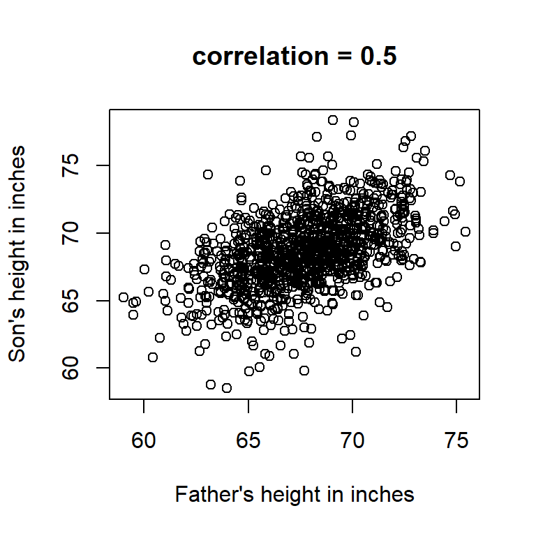

```r
data(father.son,package="UsingR")
x <- father.son$fheight
y <- father.son$sheight
plot(x,y,xlab="Father's height in inches",ylab="Son's height in inches",main=paste("correlation =",signif(cor(x,y),2)))
```

The scatter plot shows a general trend: the taller the father the taller to son. A summary of this trend is the correlation coefficient which in this case is 0.5. We motivate this statistic by trying to predict son’s height using the father’s.

Quick facts:

- Correlation’s curveball: Correlation doesn’t imply causation. Two variables can move together without one causing the other, often due to lurking third variables.
- Residual Revelations: Residuals plots, which showcase deviations from a model, can often tell more about data relationships than the fit itself, hinting at non-linearity, heteroscedasticity, or other intricacies.
- Multicollinearity Maze: In multiple regression, if predictors are too related, it can muddy interpretations.

# 2 Linear Models

Linear models are the simplest structural models. It assumes that the dependence of Y on the predictors $X_1,X_2,\dots X_p$ is linear. We represent our function like this:
$$f_L(X)=\beta_0+\beta_1X_1+\beta_2X_2+\dots\beta_pX_p$$
it has $p$ features and $p+1$ parameters $\beta$. We can estimate the parameters of the model by fitting the model to training data.

we assume a model:

$$Y=\beta_0+\beta_1X_1+\beta_2X_2+\dots\beta_pX_p+\epsilon$$

Where $\epsilon$ is some noise or errors in the function, $\beta_0$ and $\beta_p$ are unknown constants that represent the intercept and the slope, also known as coefficients or parameters.

Given some estimates $\hat{\beta_0}$ and $\hat{\beta_p}$ for the model coefficients we predict the values of Y using the model: $\hat{y} = \hat{\beta_0}+\hat{\beta_1}x+\dots\hat{\beta_p}x$ the hat symbol over the variables indicate that they are an estimated value.

A linear model is almost never correct, but it is usually a good approximation to the real function of the data. There are other models that may fit the data better, but there is a trade off in interpretability. Linear model have less prediction accuracy but are easy to interpret.

## 2.1 Correlation coefficient (Pearson)

If we standardize the values of our data, the line that we use to predict one value from the other follows a slope. That slope is the correlation.

In our substance_abuse dataset we have two variables for each observation DLA1 and DLA2 that we can plot in a scatter plot to see their relationship:

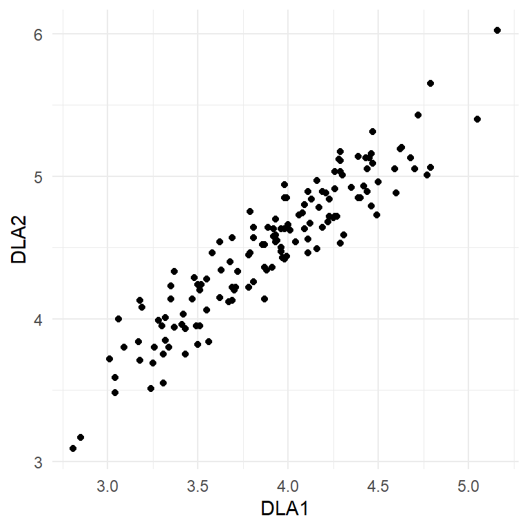

```r
file <- here::here("data", "substance_abuse.xlsx")
substance_abuse <- read_excel(file)
substance_abuse$DLA_improvement <- substance_abuse$DLA2 - substance_abuse$DLA1
treatment <- dplyr::filter(substance_abuse,
                    Program == "Intervention")

ggplot(treatment, aes(x = DLA1, y = DLA2)) +
  geom_point() # Linear
```

It shows a linear relationship between the two variables: one one increase the other tend to increase as well.

To show other possible relationships between data we will generate a dataset that shows a non-linear relationship

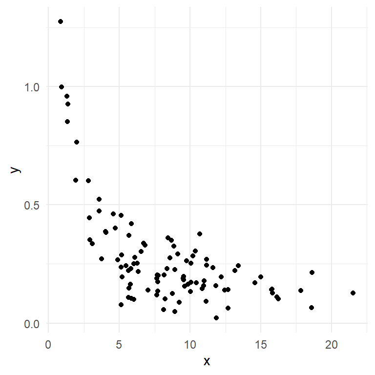

```r
set.seed(7)
x <- abs(rchisq(100, 10) - 2.7)
y <- 1/x + rnorm(100, 1, .1) - .9
data <- data.frame(x, y)
ggplot(data, aes(x = x, y = y)) +
  geom_point()
```

The **correlation coefficient formula**:

$$r = \frac{1}{n} \sum_{i=1}^{n} \left( \frac{x_i - \bar{x}}{s_x} \right) \times \left( \frac{y_i - \bar{y}}{s_y} \right) = \frac{\sum(x_i - \bar{x})(y_i - \bar{y})}{\sqrt{\sum(x_i - \bar{x})^2}\sqrt{\sum(y_i - \bar{y})^2}}
\tag{1}$$

This formula standardizes the values of ($x$) and ($y$) by subtracting their means $\bar{x}$ and $\bar{y}$ and dividing by their standard deviations $s_x$ and $s_y$, then calculates the average product of these standardized values. It’s essentially the covariance of the variables divided by the product of their standard deviations.

**Sample correlation** measures the strength of an observed **linear** relationship between two variables in a data set. Fundamentally, it measures the spread (or variability) of sample data along a line of best fit

As a convention, the variable on the horizontal axis is called **explanatory variable or predictor** and the one in the vertical axis is called **response variable.**

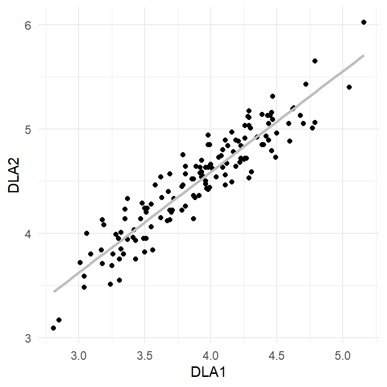

```r
 ggplot(treatment, aes(x = DLA1, y = DLA2)) +
  geom_point() +
  geom_smooth(method = "lm",
                           se = FALSE,
                           color = "grey")
```

To calculate the correlation we just have to use the command `cor()` and it’s value will go from -1 to 1. The sign of $r$ gives the direction of the association and its absolute value gives the strength. The default type of correlation for `cor()` is the Pearson correlation, so it is the same as writing `cor(x, y, method = "pearson")`

**Note**

You can use `cor()` with other types of correlation specifying them, for example:

`cor(x, y, method = “spearman”)

Since both $x$ and $y$ were standardized when computing $r$, $r$ has no units ans it is not affected by changing the center or the scale of either variable.

```r
cor(treatment$DLA1,
    treatment$DLA2)
```

```
[1] 0.930508
```

Be careful to **refer to correlation only when a pair of variables has a linear relationship**. For instance, the following variables have a clear association, but their coefficient of correlation is close to 0:

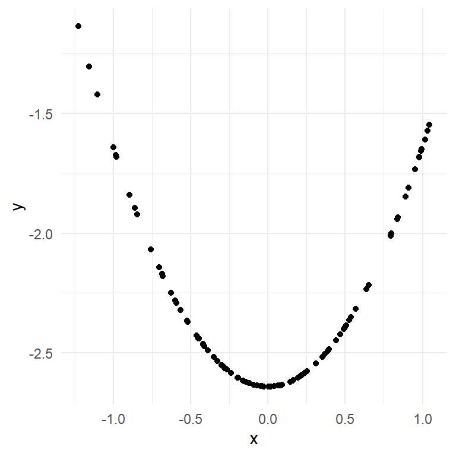

```r
set.seed(2)
x <- rnorm(100, 0, .5)
y <-  (x^2-1) + rnorm(1.5, -2.5, .8)
data <- data.frame(x, y)
ggplot(data, aes(x = x, y = y)) +
  geom_point()
```

```r
cor(x,y)
```

```
[1] 0.05255463
```

We need to be aware that when we are working with samples, we may find correlation between two variables just by random chance. For example, if we plot the variable DLA_improvement against Age we can see that there is no correlation between the two:

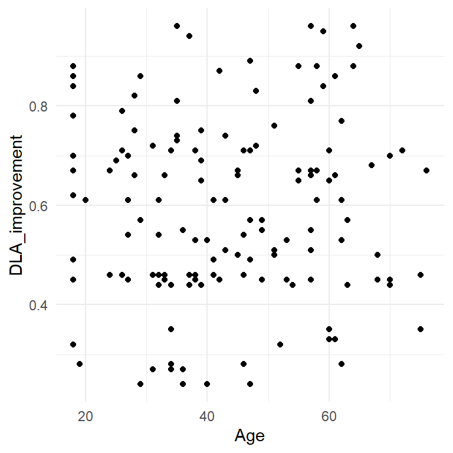

```r
ggplot(treatment, aes(Age, y = DLA_improvement)) +
  geom_point() # No association
```

```r
cor(substance_abuse$Age, substance_abuse$DLA_improvement)
```

```
[1] -0.08746504
```

but if we get a random sample of those variables, we may find some correlation:

```r
set.seed(0)

sample <- slice_sample(treatment, n = 25)
cor(sample$Age, sample$DLA_improvement)
```

```
[1] 0.3802099
```

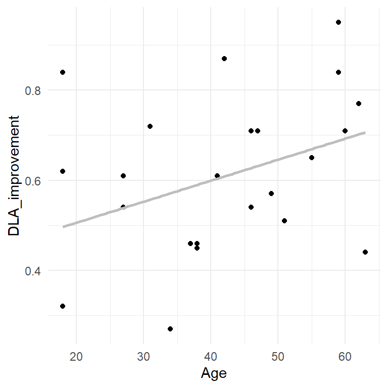

```r
ggplot(sample, aes(x = Age, y = DLA_improvement)) +
  geom_point() +
  geom_smooth(method = "lm",
              se = FALSE,
              color = "grey")
```

In the next chapters we will learn how to find out if the correlation found in our sample shows a true relationship in the population or if it is due to random chance.

Remember that we already saw that the correlation coefficient is very sensitive to outliers. (See spearman correlation)

## 2.2 Covariance

Covariance measures the extent to which two variables change together. If the variables tend to increase together, the covariance is positive. If one tends to increase while the other decreases, the covariance is negative. For variables $X$ and $Y$:
$$\text{Cov}(X, Y) = \frac{1}{n-1} \sum_{i=1}^{n} (X_i - \bar{X})(Y_i - \bar{Y}) \tag{2}$$

Covariance and correlation are related, but they’re not the same thing:

Covariance:

- Measures: The degree to which two variables change together.
- Scale: It’s dependent on the units of the variables, making it difficult to interpret the strength of the relationship.

Correlation:

- Measures: The strength and direction of the linear relationship between two variables.
- Scale: Standardizes the measure of covariance, ranging between -1 and 1.

Summary:

Covariance tells you if two variables tend to increase or decrease together, but not how strong that relationship is.

Correlation standardizes this measure, making it easier to interpret the strength and direction of the relationship on a consistent scale.

So, while covariance gives you a raw measure of how two variables vary together, correlation refines it to a standardized measure of that relationship.

Calculating the *covariance matrix* in r is easy using the `cov()` function:

```r
# Sample data frame
data <- data.frame(X = c(4, 6, 8, 10, 12), Y = c(2, 4, 6, 8, 10), Z = c(1, 2, 3, 4, 5))

# Calculate covariance matrix
cov_matrix <- cov(data)
print(cov_matrix)
```

```
   X  Y   Z
X 10 10 5.0
Y 10 10 5.0
Z  5  5 2.5
```

How to Interpret: Diagonal Elements: These are the variances of the individual variables.

- Var(X): 10.00
- Var(Y): 10.00
- Var(Z): 2.50

Off-Diagonal Elements: These are the covariances between pairs of variables.

- Cov(X, Y): 10.00
- Cov(X, Z): 5.00
- Cov(Y, Z): 5.00

Example Interpretation: Variance: The variance of X is 10, meaning X values are spread out with a variance of 10 around their mean.

Covariance (X and Y): The positive covariance of 10 between X and Y suggests that when X increases, Y tends to increase as well.

Covariance (Y and Z): The positive covariance of 5 between Y and Z also indicates a positive relationship.

In essence, the covariance matrix provides insights into how pairs of variables vary together, helping you understand relationships and dependencies in your data.

## 2.3 Regression Line and the Method of Least Squares (RSS)

If the scatterplot shows a linear association, then this relationship between our data points can be summarized by a line. The equation for a line is $\hat{y}*i=a+bx_*i$. The idea is to choose the line that minimizes the sum of the squared distances between the observed $y_i$ and the predicted $\hat{y_i}$

The method of least squares is the method we use to minimize this **Residual sum of squares (RSS)**

$$RSS=\sum_{i=1}^{n} (y_i - \hat{y}_i)^2
\tag{3}$$

$$RSS=\sum_{i=1}^{n} (y_i - \hat{y}_i)^2 = \sum_{i=1}^{n} \left( y_i - (\hat{\beta_o} + \hat{\beta_1} x_i) \right)^2$$

$$RSS = (y_1 - \beta_0 - \beta_1 x_{1})^2 + (y_2 - \beta_0 - \beta_1 x_{2})^2 + \cdots + (y_n - \beta_0 - \beta_1 x_{n})^2$$

The intercept $\beta_0$ is the expected value of Y when X=0, in other words, the value at which the regression line crosses the Y axis.

$$\hat{\beta_1}=\frac{\sum_{i=1}^n(x_i-\bar{x})(y_i-\bar{y})}{\sum_{i=1}^n(x_i-\bar{x})^2}$$
$$\hat{\beta_0}=\bar{y}-\hat{\beta_1}\bar{x}$$
where $\bar{x}$ and $\bar{y}$ are the sample means

It turns out that $\beta_1=r\frac{s_y}{s_x}$ where $r$ is the correlation coefficient and $s_y$ and $s_x$ are the two standard deviations and $\hat{\beta_0} = \bar{y} - \hat{\beta_i}\bar{x}$.

The main use of regression is to predict y from x. If we are given x, then we need $r, \bar{x},\bar{y},s_x, s_y$ to calculate the regression line. In code, we can compute that line using ‘lm’ in r language

Exercise: midterm vs final exam student’s grades (cont)

*We know that the average score for the midterm exams was 49.5 and the average score for the final exam is 69.1, and the standard deviation for the midterm exams was 10.2 while the standard deviation for the final exams was 11.8. We also know that the correlation coefficient is 0.67.*

*Predict the final exam score of a student who scored 41 on the midterm.*

Sol: 41 is 8,5 below the midterm average. We want to standardize this value. We already know how to calculate this:
$$z = \frac{x_1-\bar{x}}{sd} = \frac{41-49.5}{10.2}=-0.83$$
so now looking at the formula for the regression line we expect $y$ to be r times 0.83 times the standard deviation of the final exam below the average final score.
$$\bar{y}\pm r*sd_{final}*0.83 =69.1 -0.67*11.8*0.83=62.5$$

### 2.3.1 Predicting x from y:

When predicting x from y it is a mistake to use the regression line that we calculated for regressing y on x and solve for x. This is because regressing x on y will result in a different regression line.

## 2.4 Normal approximation in regression

Linear regression requires that the data in the scatter plot is more or less following an elypse shape. Once we have the scatter plot with the regression line, we know that given a value of $x$, the value of $y$ will be close to the $y$ point of the regression line for the $x$ value. In the image below, given $x$, we trace a vertical line to the regression line and then we trace a perpendicular line to the $y$ axis (green line) and that is approximately the expected value of $y$.

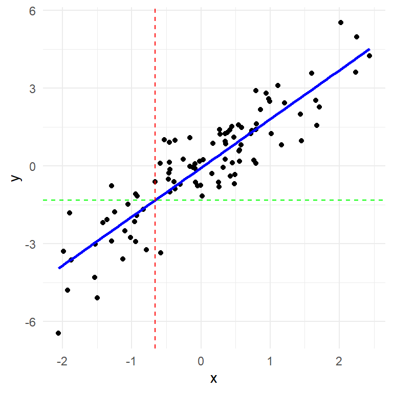

but we also know that $y$ will not be necessarily exactly at that point, but at certain distance of it, and that approximation follows the normal curve, so we can then use normal approximation to calculate the value of $y$: subtract off the predicted value $\hat{y}$, then divide by $\sqrt{1-r^2} * s_y$.

$$z = \frac{y_1-\bar{y}}{\sqrt{1-r^2}\cdot s_y}$$

Exercise:

*Among the students who scored around 41 on the midterm, what percentage scored above 60 on the final?*

We already predicted that the expected value for the score on the final exam for a student that scored 41 in midterm is 62.5. That means that the normal curve is centered at 62.5 so the percentage of students that will score above 60 is the area bellow that normal curve to the right of 60 (red line).

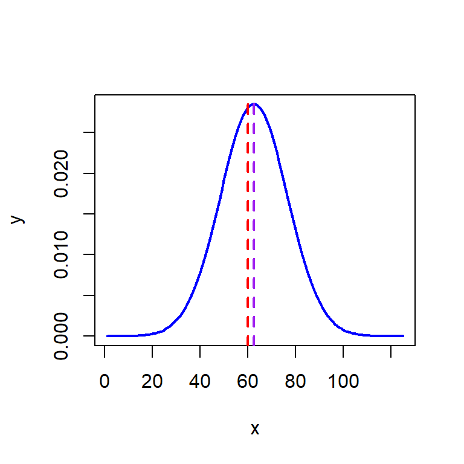

For that we standardize 60 like this: $z = \frac{y_1 - \bar{y}}{\sqrt{1 - r^2} \cdot s_y} = \frac{60 - 62.5}{\sqrt{1 - 0.67^2} \cdot 11.8} = -0.29$ so the standardized curve would look like this:

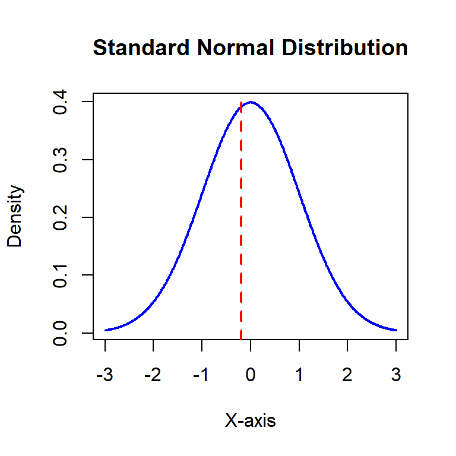

now we just have to use a table or software to calculate that value

```r
zscore <- -0.29

# Calculate the area to the left of the z-score
area_left <- pnorm(zscore)

# Calculate the area to the right of the z-score
area_right <- 1 - area_left

# Print the result
area_right
```

```
[1] 0.6140919
```

in our case we are interested to the area to the right, so our answer is 61.41%

Exercise: midterm vs final exam student’s grades

*In a biology class, both the midterm scores and the final exam scores have an average of 50 and a standard deviation of 10. The scatterplot looks football-shaped and the correlation coefficient is 0.6.*

*Emily got exactly the mean score of 50 on the midterm. What is your prediction for Emily’s score on the final?*

sol:

Since the distance in standard deviations of Emily’s midterm score from the average midterm score is 0, the corresponding distance of Emily’s predicted final score from the average final score is r*0 = 0, so our prediction is the average =50

*What is the “give or take” number for your prediction?*

sol:

$$10\sqrt{1-0.6^2} = 8$$

## 2.5 Residuals

As mentioned before, the observed values of $Y$ will not fall directly over the regression line. At each value of $X=x$ there is typically a distribution of possible $Y$ values.

For each observation we will have the predicted value $\hat{y}$ and the observed value $y$ . That difference is called the residual. The **residual plot** is a scatter plot of the residuals against the $x$ values. It should show an unstructured horizontal band and it is used to check if the regression you are using is appropriate.

For example if we have data following a linear correlation:

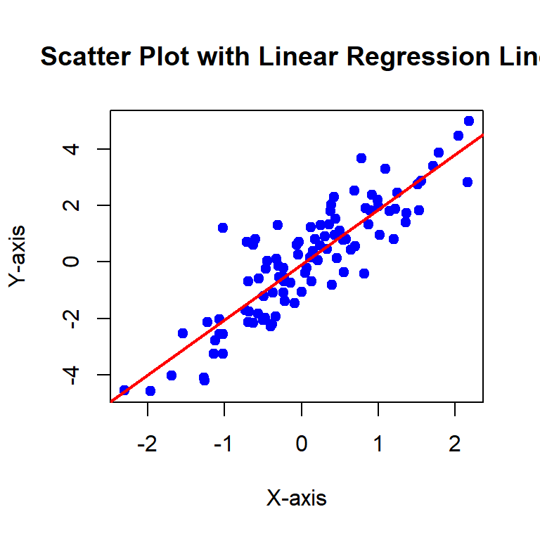

```r
#|echo = FALSE
set.seed(123)
x <- rnorm(100)
y <- 2 * x + rnorm(100)

# Create the scatter plot
plot(x, y, main = "Scatter Plot with Linear Regression Line",
     xlab = "X-axis", ylab = "Y-axis", pch = 19, col = "blue")

# Add the linear regression line
abline(lm(y ~ x), col = "red", lwd = 2)
```

the residual scatter plot will look like this:

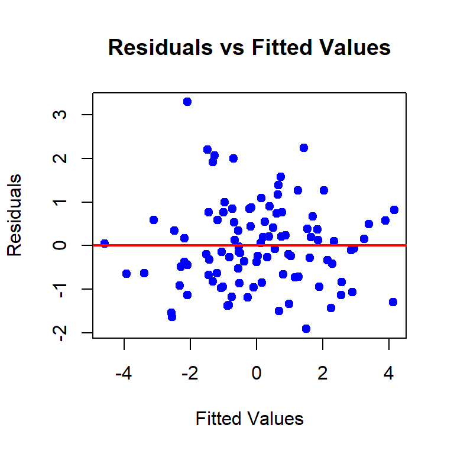

```r
model <- lm(y ~ x)

# Get the residuals and fitted values
residuals <- resid(model)
fitted_values <- fitted(model)

# Create the residual scatter plot
plot(fitted_values, residuals,
     main = "Residuals vs Fitted Values",
     xlab = "Fitted Values",
     ylab = "Residuals",
     pch = 19,
     col = "blue")

# Add a horizontal line at 0
abline(h = 0, col = "red", lwd = 2)
```

now, if we have data that does not follow a linear correlation:

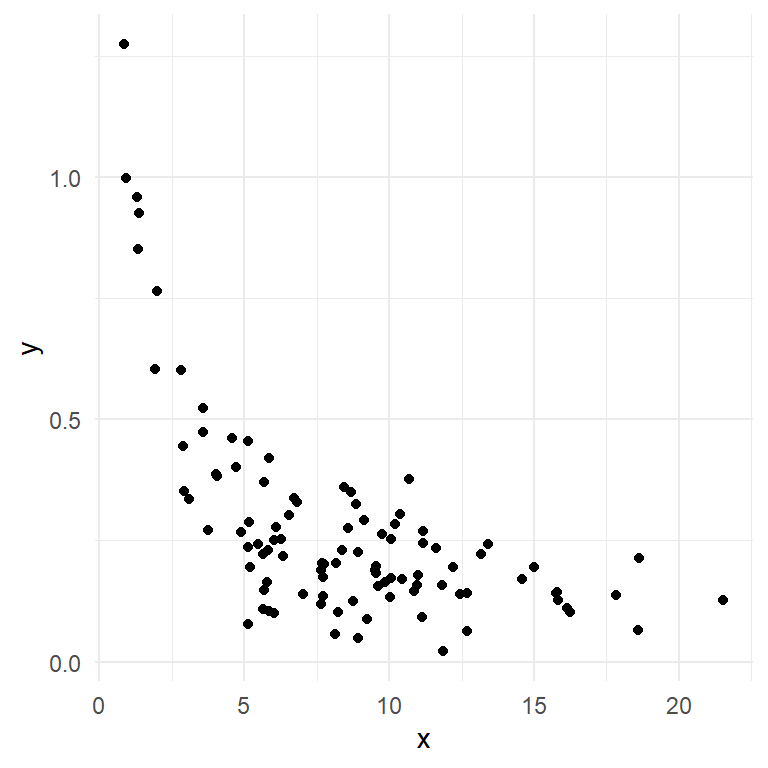

```r
#|echo = FALSE
set.seed(7)
x <- abs(rchisq(100, 10) - 2.7)
y <- 1/x + rnorm(100, 1, .1) - .9
data <- data.frame(x, y)
ggplot(data, aes(x = x, y = y)) +
  geom_point()
```

the residual will look different:

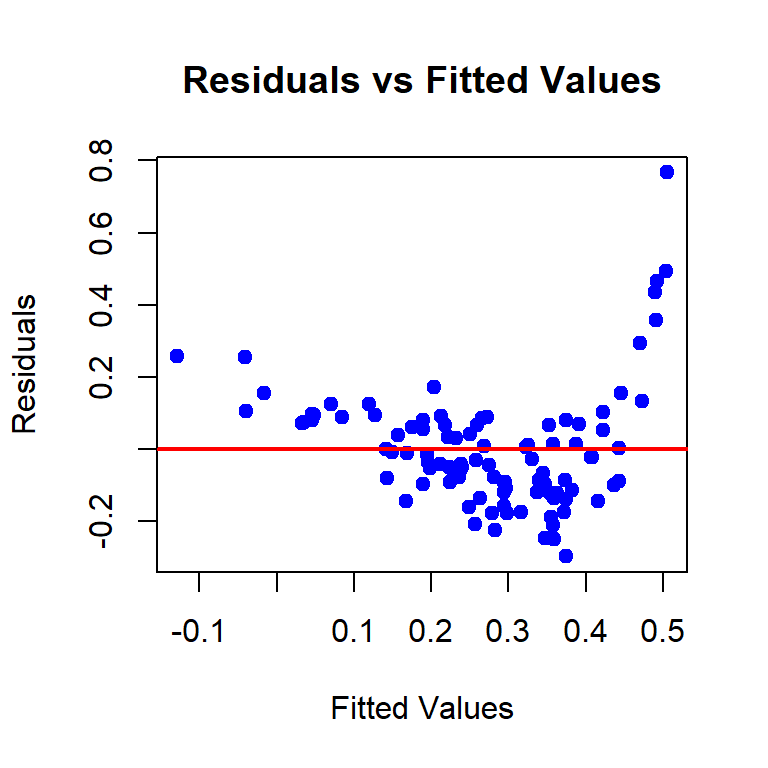

```r
#|echo = FALSE
model <- lm(y ~ x)

# Get the residuals and fitted values
residuals <- resid(model)
fitted_values <- fitted(model)

# Create the residual scatter plot
plot(fitted_values, residuals,
     main = "Residuals vs Fitted Values",
     xlab = "Fitted Values",
     ylab = "Residuals",
     pch = 19,
     col = "blue")

# Add a horizontal line at 0
abline(h = 0, col = "red", lwd = 2)
```

that is an indication that the relation is not linear, and we should not use regression for this data.

### 2.5.1 Heteroscedascidity

Another variation is when the scatter shows in a fan way, this means that the variability increases with the value of $X$, this is called heteroscedastic.

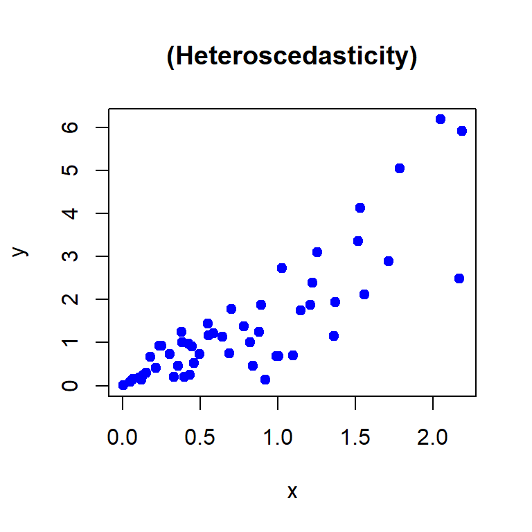

```r
#|echo = FALSE

# Generate some example data with heteroscedasticity
set.seed(123)
x <- rnorm(100)
y <- 2 * x + rnorm(100, sd = 0.9 * x)

plot(x, y,
     main = "(Heteroscedasticity)",
     pch = 19,
     xlim = c(0, max(x)),
     col = "blue")
```

Sometimes we can fix a non linear relationship by modifying y values, x values or both, for example applying log transformation.

### 2.5.2 Outliers, leverage and influential points

Points with very large residuals are called outliers and they should be examined to see if they represent an interesting phenomena or an error in the data. {#highLeverage} When the value that deviates is the $x$ value and not the $y$ we say that it is a high leverage point, and it has the potential to cause a big change in the regression line.

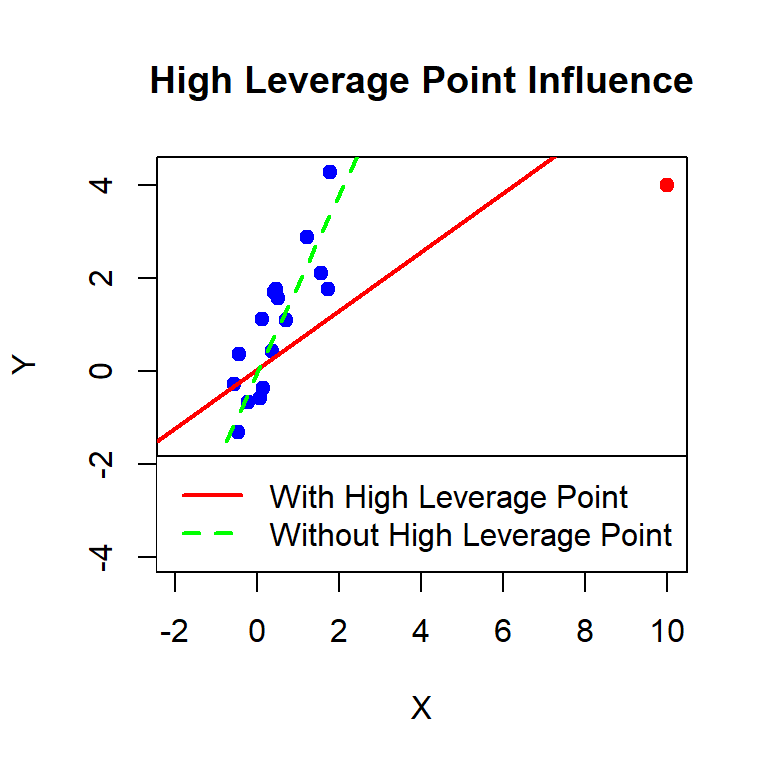

```r
#|echo = FALSE
# Generate some example data
set.seed(123)
x <- rnorm(20)
y <- 2 * x + rnorm(20)

# Add a high leverage point
x <- c(x, 10)
y <- c(y,4)

# Fit linear models
model_with_point <- lm(y ~ x)
model_without_point <- lm(y ~ x, subset = -21)

# Create the scatter plot
plot(x, y,
     main = "High Leverage Point Influence",
     xlab = "X",
     ylab = "Y",
     pch = 19,
     col = ifelse(1:21 == 21, "red", "blue"))

# Add regression lines
abline(model_with_point, col = "red", lwd = 2)
abline(model_without_point, col = "green", lwd = 2, lty = 2)

# Add a legend
legend("bottomright", legend = c("With High Leverage Point", "Without High Leverage Point"),
       col = c("red", "green"), lty = c(1, 2), lwd = 2)
```

In order to quantify and observation’s leverage we can compute the *leverage statistic*. A large value of this statistic indicates an observation with high leverage. The formula for simple linear regression is:
$$h_i=\frac{1}{n}+\frac{(x_i-\bar{x})^2}{\sum^n_{i'=1}(x_{i'}-\bar{x})^2}$$
{#leverageStatistic} There is another formula for multiple predictors, but we won’t see the formula here. The leverage statistic is always between $1/n$ and 1 and the average leverage for all the observations is always equal to $(p+1)/n$. So if a given observation has a leverage statistic that greatly exceeds $(p+1)/n$ then we may suspect that the corresponding point has leverage.

Beware of data that are summaries (e.g. averages of data). Those are less variable than individual observations and correlations between averages tend to overstate the strength of the relationship

## 2.6 Assessing the Accuracy of the Coefficient Estimates and Confidence Intervals

The *standard error* of an estimator reflects how it varies under repeated sampling.

$$SE(\hat{\beta_1})^2 = \frac{\sigma^2}{\sum_{i=1}^ n(x_i-\bar{x})^2}
\tag{4}$$
What the denominator in this formula is telling us is that the more spread out our values are along the x axis, the better we will be able to predict the correct slope.

$$SE(\hat{\beta_0})^2 = \sigma^2 \left[\frac{1}{n}+\frac{\bar{x}^2}{\sum_{i=1}^ n(x_i-\bar{x})^2}\right]
\tag{5}$$
where $\sigma^2$ is the variance of the error $\sigma^2=Var(\epsilon)$

These standard errors can be used to compute *confidence intervals* For example for 95 confidence:

$$\hat{\beta_1} \mp 2 * SE(\hat{\beta_1}) = \left[\hat{\beta_1}-2 * SE(\hat{\beta_1}),\hat{\beta_1}+2 * SE(\hat{\beta_1})\right]$$

## 2.7 Hypothesis testing and significance of correlation

The most important thing to remember about correlation testing is that **it only applies to quantitative variables that have a generally linear relationship**.

A correlation test checks the **null hypothesis that the population correlation** $\rho$ **is equal to 0**. This is, there is no relationship between X and Y. $H_0:\beta_1=0$

To test the null hypothesis, we compute a *t-statistic*
$$t= \frac{\hat{\beta_1}-0}{SE(\hat{\beta_1})}$$
This will have a t-distribution with n-2 degrees of freedom. Using statistical software, it is easy to compute the probability of observing any value equal to *t* or larger. We call this probability the $p$-value. The confidence intervals can also tell us if we should reject the null hypothesis. If 0 falls in between the range of the confidence interval, that means that we cannot exclude the possibility that the slope is 0, meaning that there is no relation between the parameters. The confidence interval is also going to tell you how big the effect is, so it is always a good practice to compute confidence intervals as well as doing a hypothesis testing.

The test **assumes that the data isn’t too skewed in any other direction and that there aren’t extreme outliers**. As usual, a larger sample provides a certain degree of protection.

**If the sample is very small, the test will be unlikely to rule out the possibility that** $\rho = 0$ even if that is the case. That is, the test will be underpowered.

Similarly, **if the sample is very large, the test will be likely to conclude that** $\rho \neq 0$ **. This gets to an important idea that we’ve touched on before which is that there is a difference between a sample statistic being statistically significant and it actually being important or meaningful. For instance in a very large sample you may get a sample correlation of 0.001 but it may come back as statistically significant. In the real world, you should always take into consideration not just statistical significance but also effect size when you make real world decisions.

```r
testResult<- cor.test(treatment$DLA2,
         treatment$DLA1)
report(testResult)
```

```
Effect sizes were labelled following Funder's (2019) recommendations.

The Pearson's product-moment correlation between treatment$DLA2 and
treatment$DLA1 is positive, statistically significant, and very large (r =
0.93, 95% CI [0.90, 0.95], t(141) = 30.17, p < .001)
```

In this type of test our null hypothesis is that the true correlation between those two variables is 0. In our example, the test is giving us a sample correlation of 0.930508 and a $p$-value 0 which in simple terms mean that the probability of getting this correlation results in our sample if the true correlation in the population was actually 0 would be less than 0.001, so highly unlikely. The test also gives us a confidence interval, in our case 0.9045168, 0.9496115 and its interpretation is exactly the same as it always is for our confidence interval: if we were to go out and get many many samples from the same population and compute correlations of them, 95% of the time that confidence interval would capture the true parameter, in our case the true population correlation.

With this new knowledge we are going to test the sample we created before showing a relationship between age and DLA_improvement and compare it with the correlation for the population (all records in our file)

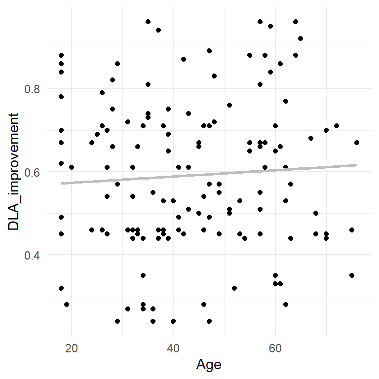

```r
#population correlation between age and dla improvement

ggplot(treatment, aes(x = Age, y = DLA_improvement)) +
  geom_point() +
  geom_smooth(method = "lm",
              se = FALSE,
              color = "grey")
```

```r
report(cor.test(treatment$Age,
         treatment$DLA_improvement))
```

```
Effect sizes were labelled following Funder's (2019) recommendations.

The Pearson's product-moment correlation between treatment$Age and
treatment$DLA_improvement is positive, statistically not significant, and very
small (r = 0.06, 95% CI [-0.10, 0.22], t(141) = 0.74, p = 0.461)
```

```r
#small sample correlation:
set.seed(0)
sample <- slice_sample(treatment, n = 25)
report(cor.test(sample$Age,
         sample$DLA_improvement))
```

```
Effect sizes were labelled following Funder's (2019) recommendations.

The Pearson's product-moment correlation between sample$Age and
sample$DLA_improvement is positive, statistically not significant, and large (r
= 0.38, 95% CI [-0.02, 0.67], t(23) = 1.97, p = 0.061)
```

A significant correlation means that the likelihood of observing such a correlation (or stronger) by random chance is low, given the null hypothesis of no correlation.